# Mini-Project #02: Identifying Environmentally Responsible US Public Transit Systems

## Task 2: Initial Analysis of SEP Data

### Which state has the most expensive retail electricity?

```r
most_expensive <- EIA_SEP_REPORT[which.max(EIA_SEP_REPORT$electricity_price_MWh), ]
most_expensive_state <- most_expensive$state
most_expensive_price <- most_expensive$electricity_price_MWh

cat("The state with the most expensive retail electricity is:", most_expensive_state,
    "with a price of $", round(most_expensive_price, 2), "per MWh.\n")
```

```
The state with the most expensive retail electricity is: Hawaii with a price of $ 386 per MWh.
```

### Which state has the ‘dirtiest’ electricity mix?

```r
dirtiest <- EIA_SEP_REPORT[which.max(EIA_SEP_REPORT$CO2_MWh), ]
dirtiest_state <- dirtiest$state
dirtiest_co2 <- dirtiest$CO2_MWh

cat("The state with the dirtiest electricity mix is:", dirtiest_state,
    "with", dirtiest_co2, "lbs of CO2 emitted per MWh.\n")
```

```
The state with the dirtiest electricity mix is: West Virginia with 1925 lbs of CO2 emitted per MWh.
```

### Average CO2 emissions per MWh across the US (weighted by generation)

```r
total_weighted_co2 <- sum(EIA_SEP_REPORT$CO2_MWh * EIA_SEP_REPORT$generation_MWh, na.rm = TRUE)


total_generation <- sum(EIA_SEP_REPORT$generation_MWh, na.rm = TRUE)


weighted_avg_co2 <- total_weighted_co2 / total_generation

cat("The weighted average of CO2 emissions per MWh in the US is:", round(weighted_avg_co2, 2), "lbs.\n")
```

```
The weighted average of CO2 emissions per MWh in the US is: 805.37 lbs.
```

### Rarest primary energy source

```r
primary_counts <- EIA_SEP_REPORT %>%
  group_by(primary_source) %>%
  summarize(count = n(), .groups = "drop") %>%
  arrange(count)


rarest_source <- primary_counts$primary_source[1]

rarest_info <- EIA_SEP_REPORT %>%
  filter(primary_source == rarest_source) %>%
  select(state, electricity_price_MWh, primary_source)

cat("The rarest primary energy source is:", rarest_source,
    "used in", rarest_info$state,
    "with an electricity price of $", round(rarest_info$electricity_price_MWh, 2), "per MWh.\n")
```

```
The rarest primary energy source is: Petroleum used in Hawaii with an electricity price of $ 386 per MWh.
```

### Comparing New York and Texas energy mix

```r
ny_data <- EIA_SEP_REPORT %>% filter(state == "New York")
tx_data <- EIA_SEP_REPORT %>% filter(state == "Texas")


times_cleaner <- tx_data$CO2_MWh / ny_data$CO2_MWh

cat("New York's electricity is", round(times_cleaner, 2),
    "times cleaner than Texas's electricity.\n")
```

```
New York's electricity is 1.64 times cleaner than Texas's electricity.
```

```r
cat("New York emits", ny_data$CO2_MWh, "lbs CO2/MWh compared to",
    tx_data$CO2_MWh, "lbs CO2/MWh for Texas.\n")
```

```
New York emits 522 lbs CO2/MWh compared to 855 lbs CO2/MWh for Texas.
```

Let’s visualize the electricity cleanliness by state:

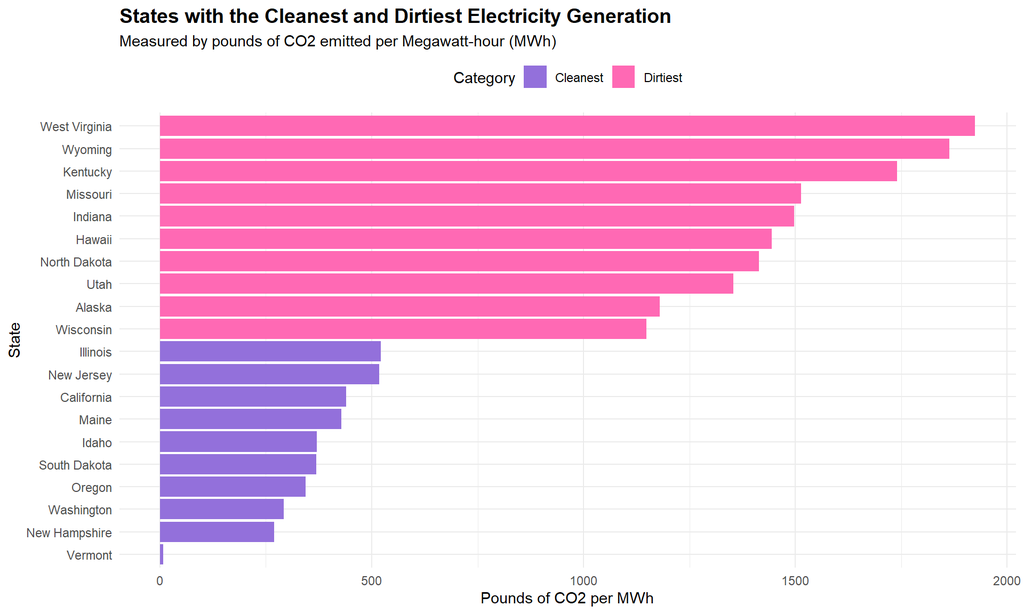

```r
#Plot of the top 10 cleanest and dirtiest states by CO2 emissions
clean_states <- EIA_SEP_REPORT %>%
  arrange(CO2_MWh) %>%
  slice(1:10)

dirty_states <- EIA_SEP_REPORT %>%
  arrange(desc(CO2_MWh)) %>%
  slice(1:10)

electricity_comparison <- bind_rows(
  clean_states %>% mutate(category = "Cleanest"),
  dirty_states %>% mutate(category = "Dirtiest")
)


my_colors <- c("Cleanest" = "#9370DB", "Dirtiest" = "#FF69B4")

ggplot(electricity_comparison, aes(x = reorder(state, CO2_MWh), y = CO2_MWh, fill = category)) +
  geom_bar(stat = "identity") +
  coord_flip() +
  scale_fill_manual(values = my_colors) +
  labs(
    title = "States with the Cleanest and Dirtiest Electricity Generation",
    subtitle = "Measured by pounds of CO2 emitted per Megawatt-hour (MWh)",
    x = "State",
    y = "Pounds of CO2 per MWh",
    fill = "Category"
  ) +
  theme_minimal() +
  theme(
    plot.title = element_text(face = "bold", size = 14),
    legend.position = "top"
  )
```

This visualization clearly shows the stark contrast between the cleanest and dirtiest electricity generation across states, which will directly impact the environmental footprint of electric transit systems in these regions.

## 2023 Annual Database Energy Consumption

Let’s import and clean the 2023 Annual Database Energy Consumption report:

```r
ensure_package(readxl)

DATA_DIR <- file.path("data", "mp02")
dir.create(DATA_DIR, showWarnings=FALSE, recursive=TRUE)

NTD_ENERGY_FILE <- file.path(DATA_DIR, "2023_ntd_energy.xlsx")

if(!file.exists(NTD_ENERGY_FILE)){
    DS <- download.file("https://www.transit.dot.gov/sites/fta.dot.gov/files/2024-10/2023%20Energy%20Consumption.xlsx",
                  destfile=NTD_ENERGY_FILE,
                  method="curl")

    if(DS | (file.info(NTD_ENERGY_FILE)$size == 0)){
        cat("I was unable to download the NTD Energy File. Please try again.\n")
        stop("Download failed")
    }
}

NTD_ENERGY_RAW <- read_xlsx(NTD_ENERGY_FILE)

ensure_package(tidyr)

to_numeric_fill_0 <- function(x){

    x_char <- as.character(x)

    x_clean <- gsub("[^0-9.-]", "", x_char)

    numeric_values <- suppressWarnings(as.numeric(x_clean))

    replace_na(numeric_values, 0)
}


NTD_ENERGY <- suppressWarnings({
  NTD_ENERGY_RAW |>
    select(-c(`Reporter Type`,
              `Reporting Module`,
              `Other Fuel`,
              `Other Fuel Description`)) |>
    mutate(across(-c(`Agency Name`,
                     `Mode`,
                     `TOS`),
                  to_numeric_fill_0)) |>
    group_by(`NTD ID`, `Mode`, `Agency Name`) |>
    summarize(across(where(is.numeric), sum),
              .groups = "keep") |>
    mutate(ENERGY = sum(c_across(c(where(is.numeric))))) |>
    filter(ENERGY > 0) |>
    select(-ENERGY) |>
    ungroup()
})
```

Let’s preview the NTD Energy data:

```r
slice_sample(NTD_ENERGY, n = 5) %>%
  select(`NTD ID`, `Mode`, `Agency Name`, `Diesel Fuel`, `Electric Propulsion`) %>%
  kable(caption = "Sample of NTD Energy Data") %>%
  kable_styling(bootstrap_options = "striped", full_width = FALSE)
```

Sample of NTD Energy Data

| NTD ID | Mode | Agency Name | Diesel Fuel | Electric Propulsion |
| --- | --- | --- | --- | --- |
| 40037 | MB | Board of County Commissioners, Palm Beach County | 1916209 | 0 |
| 20003 | MB | Broome County | 252281 | 0 |
| 90015 | MB | City and County of San Francisco | 3839667 | 0 |
| 90131 | MB | City of Scottsdale | 68723 | 0 |
| 20018 | DR | Central New York Regional Transportation Authority | 0 | 0 |

## Task 3: Recoding the Mode column

First, let’s look at the unique Mode codes in our data:

```r
unique_modes <- NTD_ENERGY %>%
  distinct(Mode) %>%
  pull(Mode) %>%
  sort()

cat("Unique mode codes in the data:", paste(unique_modes, collapse = ", "))
```

```
Unique mode codes in the data: AR, CB, CC, CR, DR, FB, HR, IP, LR, MB, MG, PB, RB, SR, TB, TR, VP, YR
```

Now I’ll recode these mode codes based on the NTD definitions:

```r
NTD_ENERGY <- NTD_ENERGY %>%
  mutate(Mode = case_when(
    Mode == "AR" ~ "Alaska Railroad",
    Mode == "CB" ~ "Commuter Bus",
    Mode == "CC" ~ "Cable Car",
    Mode == "CR" ~ "Commuter Rail",
    Mode == "DR" ~ "Demand Response",
    Mode == "DT" ~ "Demand Response Taxi",
    Mode == "FB" ~ "Ferry Boat",
    Mode == "HR" ~ "Heavy Rail",
    Mode == "IP" ~ "Inclined Plane",
    Mode == "LR" ~ "Light Rail",
    Mode == "MB" ~ "Bus",
    Mode == "MG" ~ "Monorail/Automated Guideway",
    Mode == "OR" ~ "Other Rail",
    Mode == "RB" ~ "Bus Rapid Transit",
    Mode == "SR" ~ "Street Car Rail",
    Mode == "TB" ~ "Trolleybus",
    Mode == "TR" ~ "Aerial Tramway",
    Mode == "VP" ~ "Vanpool",
    Mode == "YR" ~ "Hybrid Rail",
    TRUE ~ "Unknown"
  ))


NTD_ENERGY %>%
  group_by(Mode) %>%
  summarize(count = n()) %>%
  arrange(desc(count)) %>%
  head(10) %>%
  kable(caption = "Top 10 Transit Modes After Recoding") %>%
  kable_styling(bootstrap_options = "striped", full_width = FALSE)
```

Top 10 Transit Modes After Recoding

| Mode | count |
| --- | --- |
| Bus | 411 |
| Demand Response | 401 |
| Vanpool | 85 |
| Commuter Bus | 76 |
| Ferry Boat | 29 |
| Commuter Rail | 27 |
| Street Car Rail | 24 |
| Light Rail | 22 |
| Bus Rapid Transit | 17 |
| Heavy Rail | 16 |

## Importing 2023 Annual Database Service by Agency

```r
NTD_SERVICE_FILE <- file.path(DATA_DIR, "2023_service.csv")
if(!file.exists(NTD_SERVICE_FILE)){
    DS <- download.file("https://data.transportation.gov/resource/6y83-7vuw.csv",
                  destfile=NTD_SERVICE_FILE,
                  method="curl")

    if(DS | (file.info(NTD_SERVICE_FILE)$size == 0)){
        cat("I was unable to download the NTD Service File. Please try again.\n")
        stop("Download failed")
    }
}

NTD_SERVICE_RAW <- read_csv(NTD_SERVICE_FILE, show_col_types = FALSE)

NTD_SERVICE <- NTD_SERVICE_RAW %>%
  mutate(`NTD ID` = as.numeric(`_5_digit_ntd_id`)) %>%
  rename(Agency = agency,
         City   = max_city,
         State  = max_state,
         UPT    = sum_unlinked_passenger_trips_upt,
         MILES  = sum_passenger_miles) %>%
  select(matches("^[A-Z]", ignore.case=FALSE)) %>%
  filter(MILES > 0)
```

Let’s preview the service data:

```r
head(NTD_SERVICE, 5) %>%
  select(Agency, City, State, UPT, MILES) %>%
  mutate(
    UPT = number(UPT, big.mark = ","),
    MILES = number(MILES, big.mark = ",")
  ) %>%
  kable(caption = "Preview of NTD Service Data") %>%
  kable_styling(bootstrap_options = "striped", full_width = FALSE)
```

Preview of NTD Service Data

| Agency | City | State | UPT | MILES |
| --- | --- | --- | --- | --- |
| King County, dba: King County Metro | Seattle | WA | 78,886,848 | 301,530,502 |
| Spokane Transit Authority | Spokane | WA | 9,403,739 | 46,318,134 |
| Pierce County Transportation Benefit Area Authority, dba: Pierce Transit | Lakewood | WA | 6,792,245 | 40,362,320 |
| City of Everett, dba: Everett Transit | Everett | WA | 1,404,970 | 5,193,721 |
| City of Yakima, dba: Yakima Transit | Yakima | WA | 646,711 | 3,435,365 |

## Task 4: Explore NTD Service Data

### Which transit service has the most UPT annually?

```r
most_upt <- NTD_SERVICE %>%
  arrange(desc(UPT)) %>%
  slice(1)

cat("The transit service with the most annual Unlinked Passenger Trips is:",
    most_upt$Agency, "in", most_upt$City, most_upt$State,
    "with", format(most_upt$UPT, big.mark = ","), "trips.")
```

```
The transit service with the most annual Unlinked Passenger Trips is: MTA New York City Transit in Brooklyn NY with 2,632,003,044 trips.
```

### What is the average trip length of a trip on MTA NYC?

```r
mta_nyc <- NTD_SERVICE %>%
  filter(grepl("MTA", Agency, ignore.case = TRUE) &
           grepl("New York", City, ignore.case = TRUE))

mta_nyc_summary <- mta_nyc %>%
  summarize(
    total_miles = sum(MILES, na.rm = TRUE),
    total_upt = sum(UPT, na.rm = TRUE),
    average_trip_length = total_miles / total_upt
  )

cat("The average trip length on MTA NYC is",
    round(mta_nyc_summary$average_trip_length, 2), "miles.")
```

```
The average trip length on MTA NYC is 13.08 miles.
```

### Which transit service in NYC has the longest average trip length?

```r
nyc_agencies <- NTD_SERVICE %>%
  filter(grepl("New York|NYC|Brooklyn", City)) %>%
  mutate(avg_trip_length = MILES / UPT) %>%
  arrange(desc(avg_trip_length))

longest_nyc_trip <- nyc_agencies %>% slice(1)

cat("The NYC transit service with the longest average trip length is",
    longest_nyc_trip$Agency, "with an average of",
    round(longest_nyc_trip$avg_trip_length, 2), "miles per trip.")
```

```
The NYC transit service with the longest average trip length is MTA Long Island Rail Road with an average of 24.26 miles per trip.
```

### Which state has the fewest total miles travelled by public transit?

```r
state_miles <- NTD_SERVICE %>%
  group_by(State) %>%
  summarize(total_miles = sum(MILES)) %>%
  arrange(total_miles)

fewest_miles <- state_miles %>% slice(1)

cat("The state with the fewest total public transit miles is",
    fewest_miles$State, "with", format(fewest_miles$total_miles, big.mark = ","), "miles.")
```

```
The state with the fewest total public transit miles is NH with 3,749,892 miles.
```

### Are all states represented in this data? If no, which ones are missing?

```r
states_in_data <- NTD_SERVICE %>%
  distinct(State) %>%
  pull(State)

missing_states <- setdiff(state.abb, states_in_data)


missing_state_names <- state.name[match(missing_states, state.abb)]

cat("There are", length(missing_state_names), "states missing from the data:\n")
```

```
There are 19 states missing from the data:
```

```r
cat(paste(missing_state_names, collapse = ", "))
```

```
Arizona, Arkansas, California, Colorado, Hawaii, Iowa, Kansas, Louisiana, Missouri, Montana, Nebraska, Nevada, New Mexico, North Dakota, Oklahoma, South Dakota, Texas, Utah, Wyoming
```

Let’s visualize the transit service coverage by state:

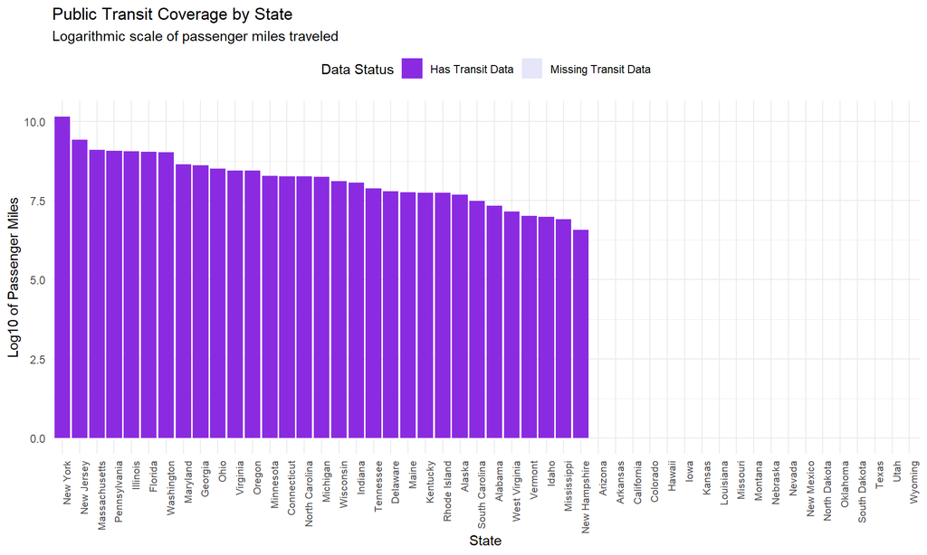

```r
all_states <- data.frame(
  State = state.abb,
  state_name = state.name,
  status = ifelse(state.abb %in% states_in_data, "Has Transit Data", "Missing Transit Data")
)


state_service <- NTD_SERVICE %>%
  group_by(State) %>%
  summarize(
    total_miles = sum(MILES),
    total_upt = sum(UPT)
  )

all_states <- all_states %>%
  left_join(state_service, by = "State") %>%
  mutate(
    total_miles = ifelse(is.na(total_miles), 0, total_miles),
    total_upt = ifelse(is.na(total_upt), 0, total_upt),
    log_miles = ifelse(total_miles > 0, log10(total_miles), NA)
  )


ggplot(all_states, aes(x = reorder(state_name, -total_miles), y = log_miles, fill = status)) +
  geom_bar(stat = "identity") +
  scale_fill_manual(values = c("Has Transit Data" = "#8a2be2", "Missing Transit Data" = "#e6e6fa")) +
  labs(
    title = "Public Transit Coverage by State",
    subtitle = "Logarithmic scale of passenger miles traveled",
    x = "State",
    y = "Log10 of Passenger Miles",
    fill = "Data Status"
  ) +
  theme_minimal() +
  theme(
    axis.text.x = element_text(angle = 90, hjust = 1, size = 8),
    legend.position = "top"
  )
```